# 9: Neural Networks, Transfer Learning and Transformer Models

Michael Jacobs

# Motivation and Overview

## Recap

**Last week:**

- Dense vector representations of **words** $\rightarrow$ dense vector representations of **sentences**
- We did this with the help of **neural network language models**

**This week:**

- How do neural network language models work?
- How can we train/fine-tune our own model for classification?

## Why Use Neural Language Models?

- Better performance in supervised **classification** of documents
- Models can be adapted for new tasks using **transfer learning**
  - e.g. Fine-tune sentiment classifier to specific domain
  - Zero-shot classification
- Can also be used for **text generation**
  - Text summarisation
  - Translation
  - Chatbots

## Roadmap

1. Neural networks: foundations
2. Neural language modelling
- Feed forward neural networks
- Recurrent neural networks
- Transformer architecture
3. Transfer learning
- Pretraining
- Fine tuning
- BERT, BERT+classifier, BERT-NLI
4. Practical considerations

# Neural networks: foundations

## What is a Neural Network?

A **neural network** is a complex and highly flexible function that converts a set of numerical inputs into a set of numerical outputs.

Inputs:

| Var | Value |
| --- | --- |
| Age | 24 |
| Male | 0 |
| Height | 174 |

$\rightarrow$

Outputs:

| Class | Prob |
| --- | --- |
| Right-handed | 0.63 |
| Left-handed | 0.36 |

## What is a Neural Network?

A **neural network** is a complex and highly flexible function that converts a set of numerical inputs into a set of numerical outputs.

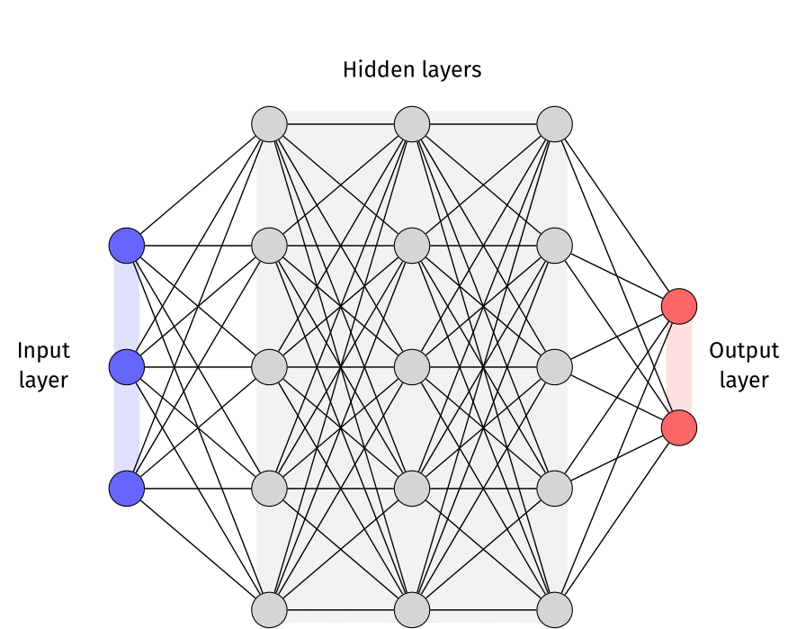

## What is a Neural Network?

It’s composed of:

- Input layer
- Hidden layers
- Output layer

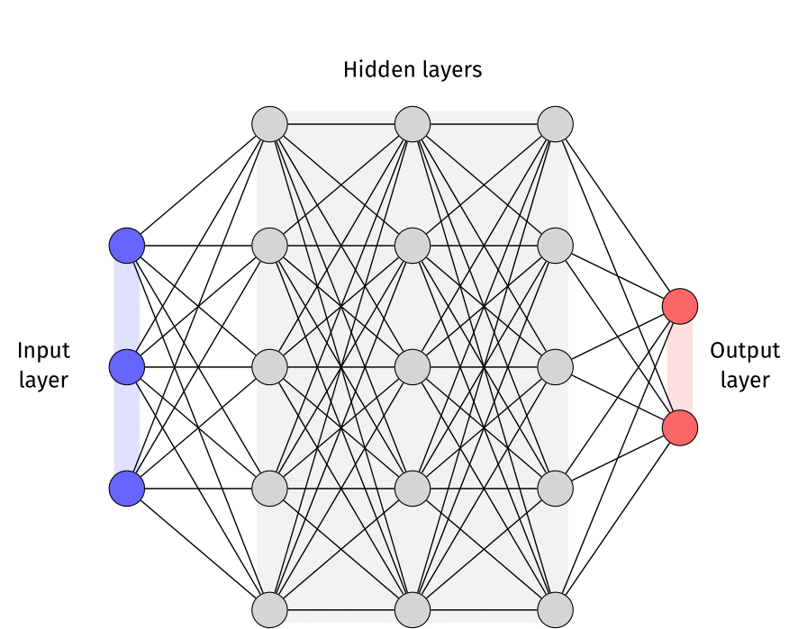

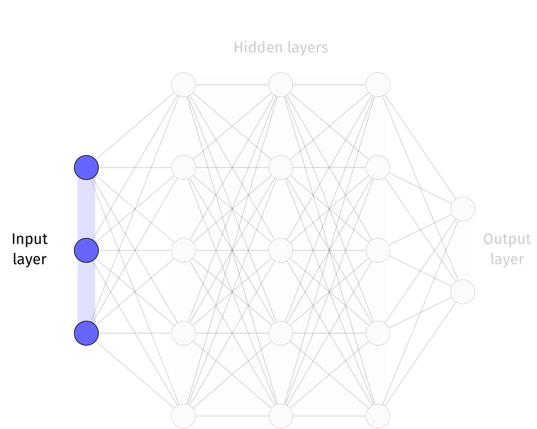

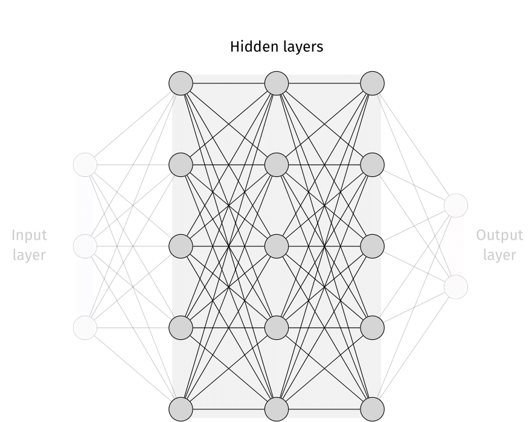

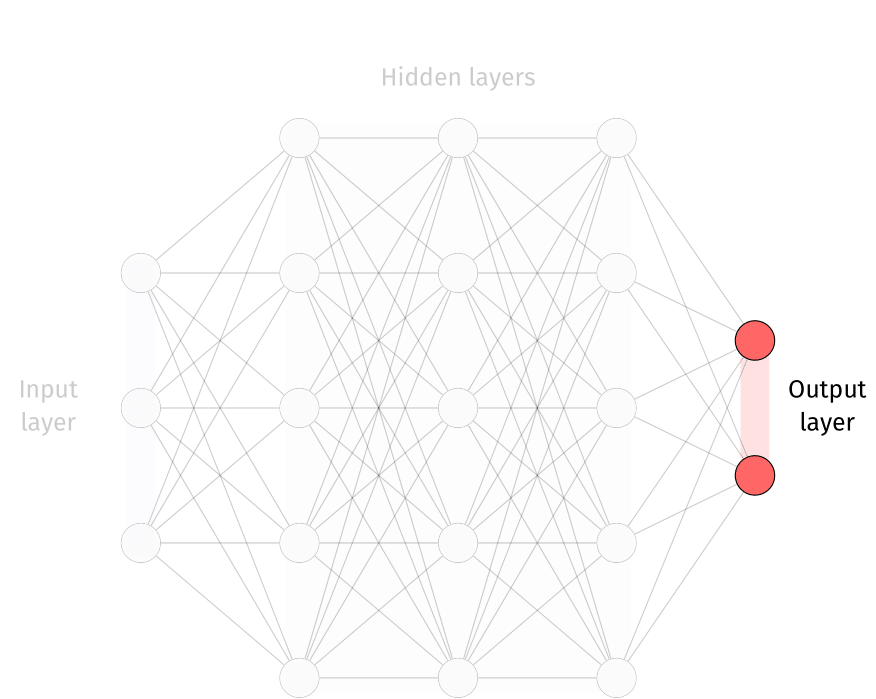

## What is a Neural Network?

Each node takes in the values from nodes in the previous layer…

… processes them, and passes on the output to the next layer…

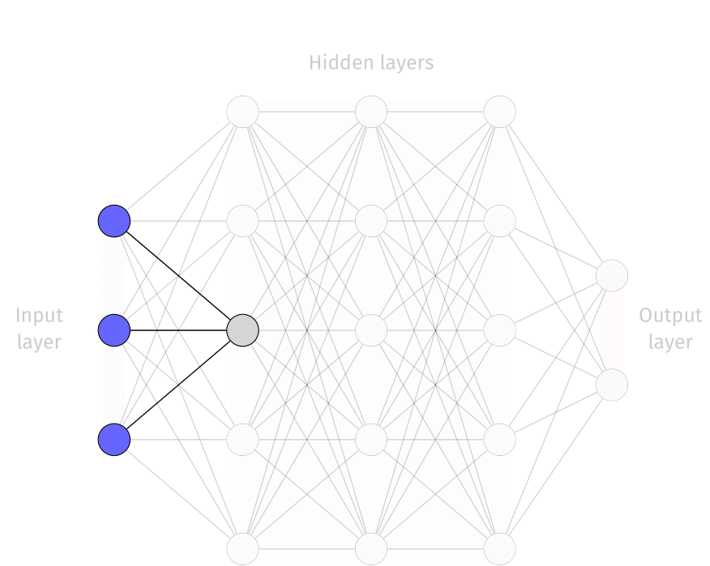

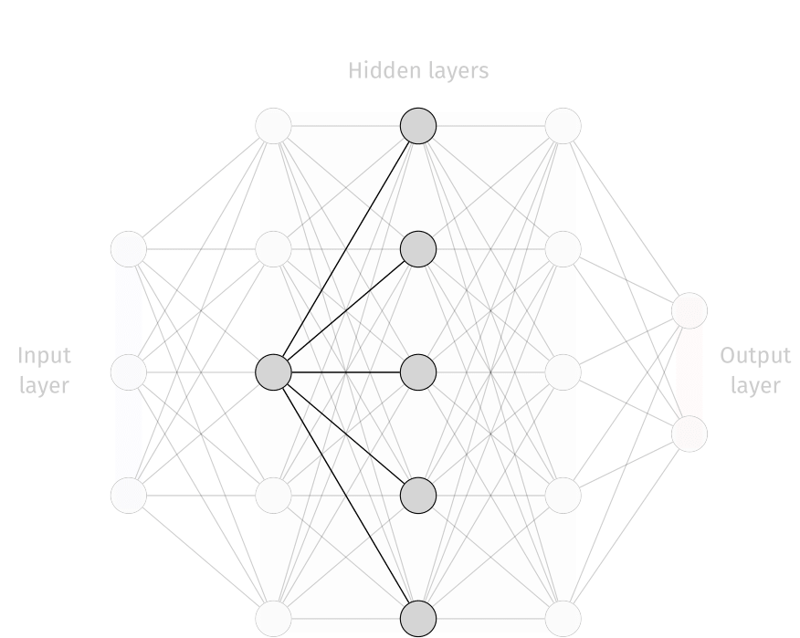

## Inside a single node

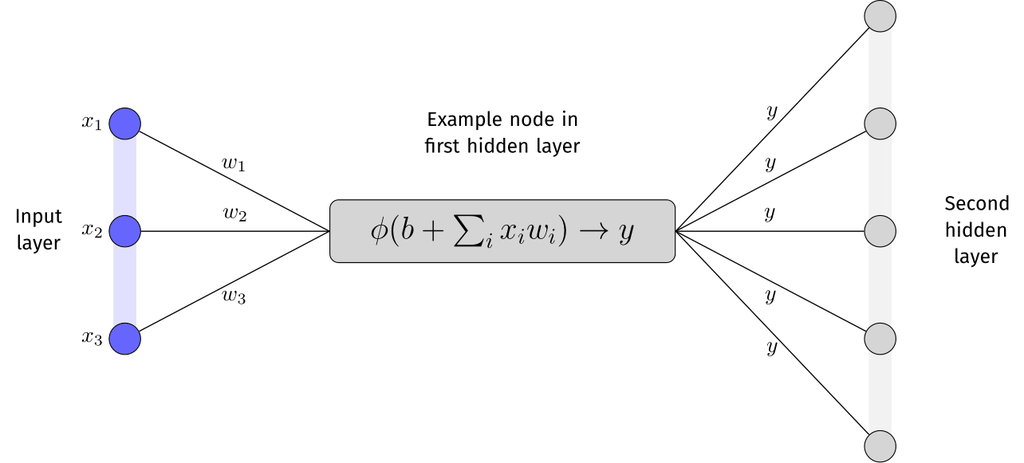

## Activation functions

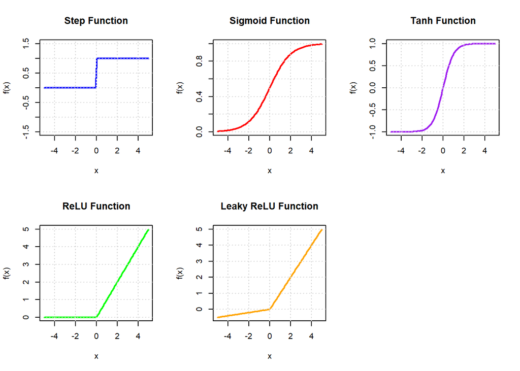

## Output layer

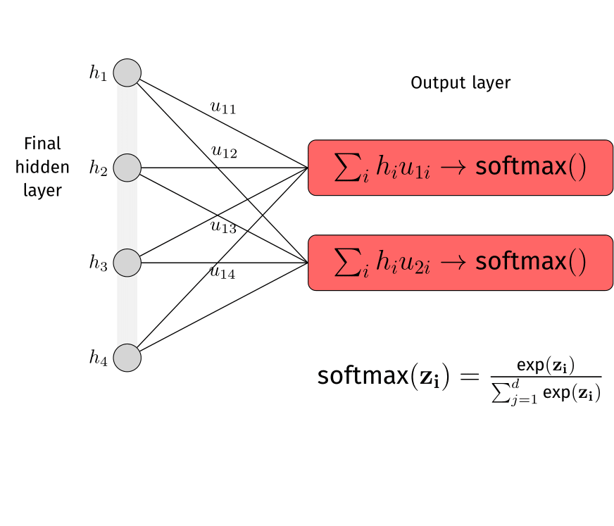

## Why are Neural Networks so Powerful?

- Neural networks have an extremely flexible functional form.
  - *Universal Approximation Theorem*: a neural network can approximate any function.
- This flexibility comes at the price of a very large number of **trainable parameters**.
  - N. Param $\approx L \times (n^2 + n)$
  - $L$ is N of layers; $n$ is nodes per layer
  - e.g. $L=3$, $n=100$, N. Param = $30,300$
- This calls for a large quantity of **training data**

More flexible functional forms can approximate more complex relationships…

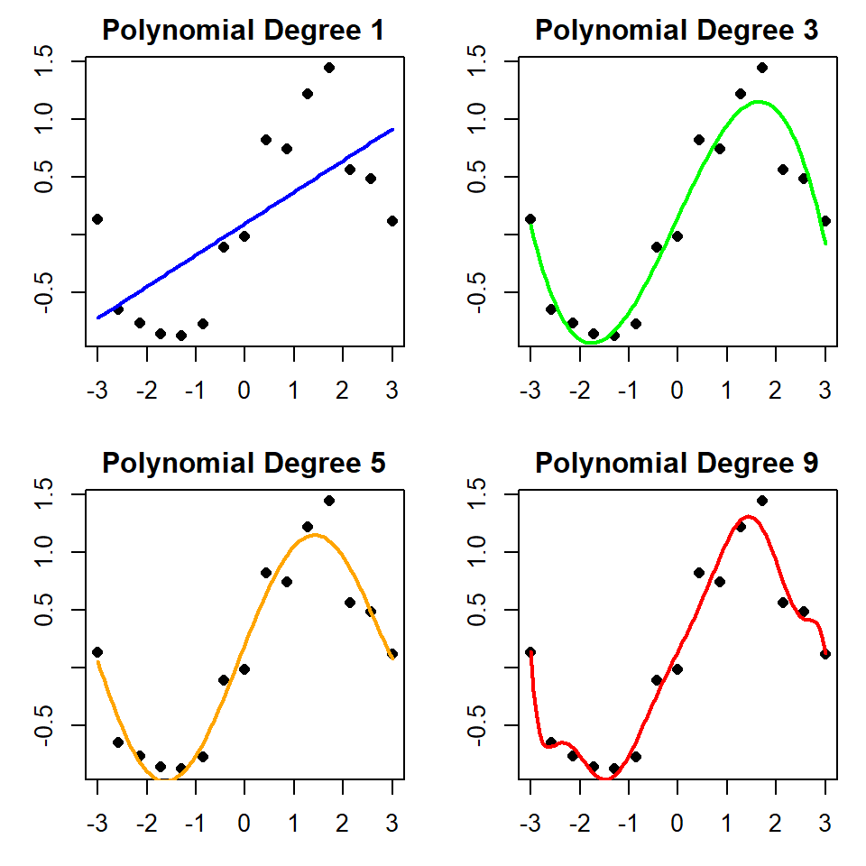

## Training a Neural Network

#### Prerequisites

- **A task:** e.g. classify left v right handed
- **A loss function** e.g. $L(\hat{y}, y) = -\sum_k \mathbf{y}_k\text{log}(\mathbf{\hat{y}}_k)$
- **Labelled data**: [0, 1, 1, 0, 1, 0]

#### Steps

1. **Initialise** the model parameters randomly.
2. **Forward pass** through the model
3. **Calculate loss** using outputs
4. **Backpropagation** (work out gradients of loss)
- Calculate change in loss given change in weight: $\frac{\partial L(\hat{y}, y)}{\partial w_j}$
5. **Update parameters** using gradient descent
- $w_{t+1} = w_{t} - \eta \frac{\partial L}{\partial w_{t}}$
6. **Repeat until convergence**

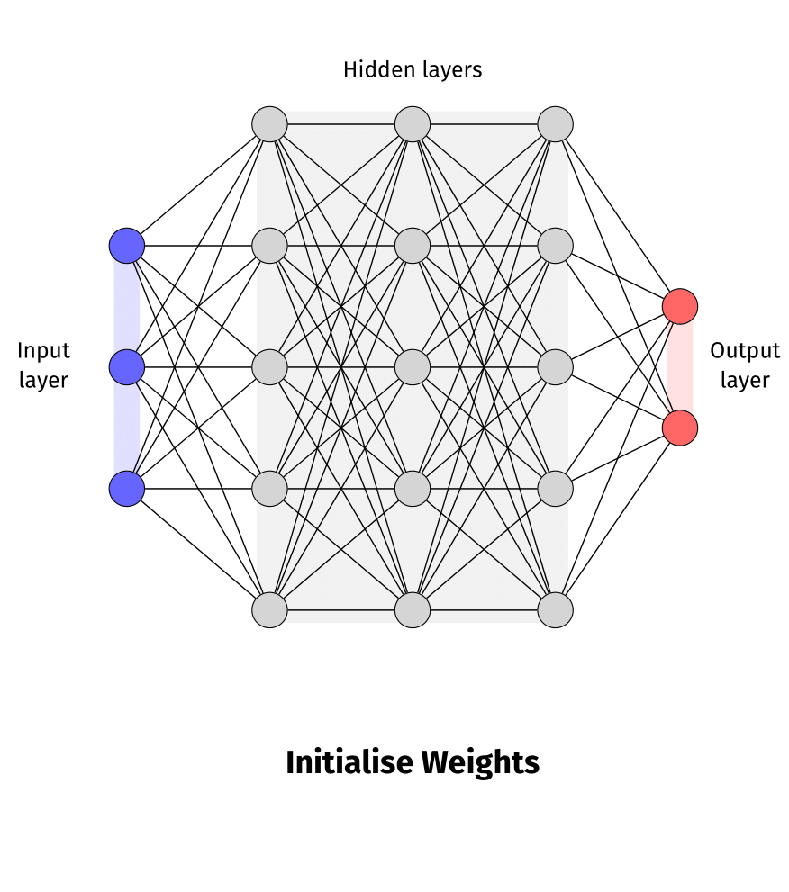

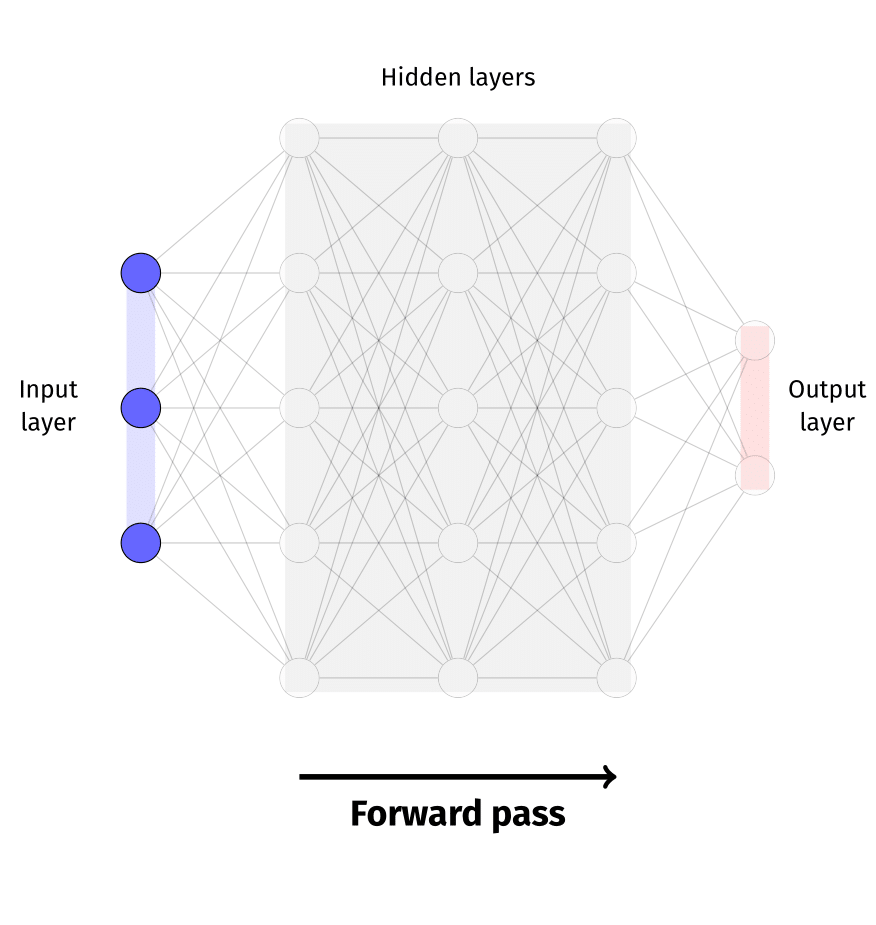

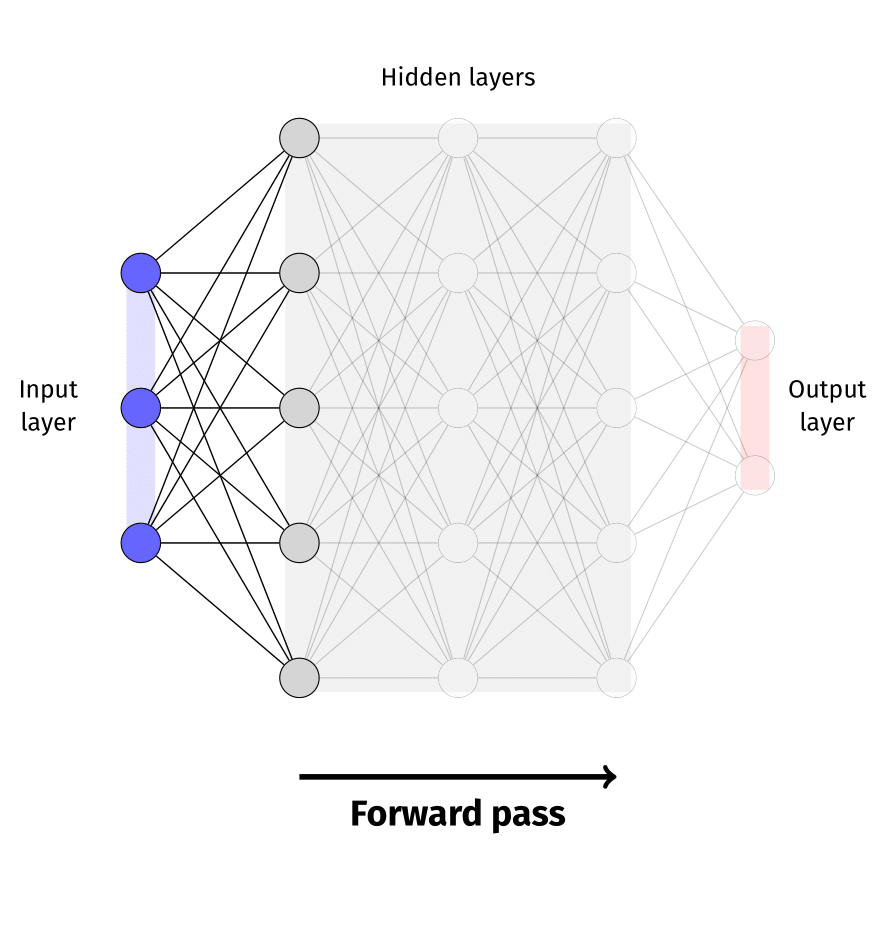

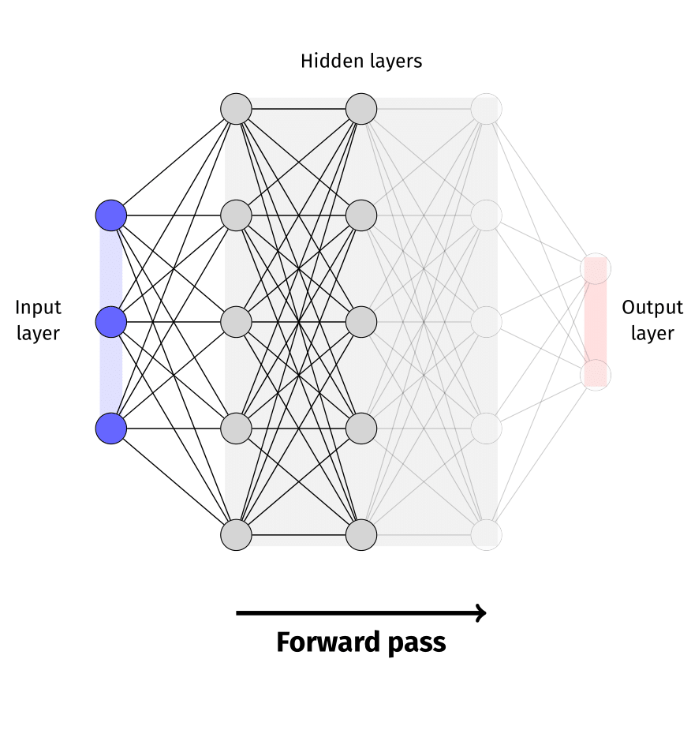

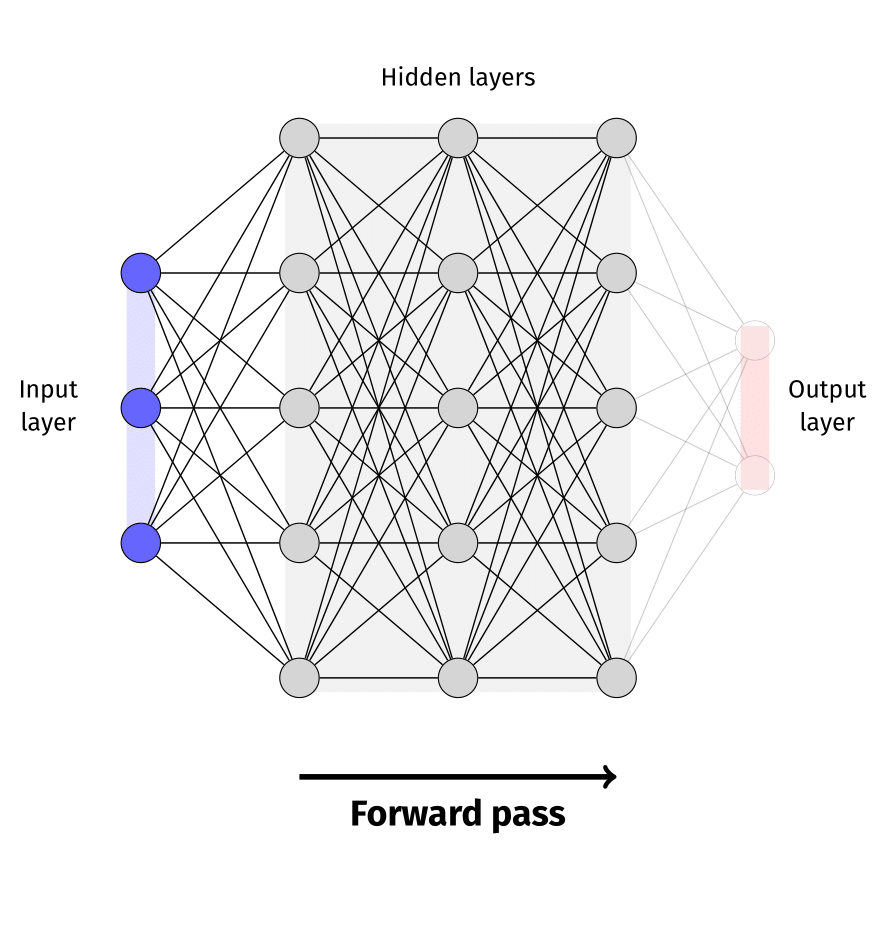

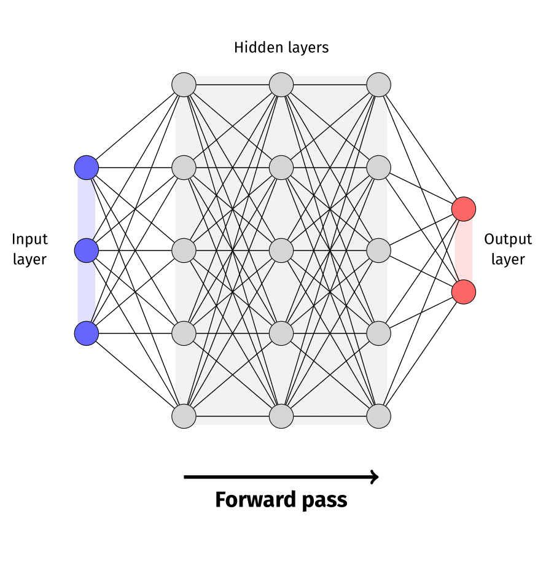

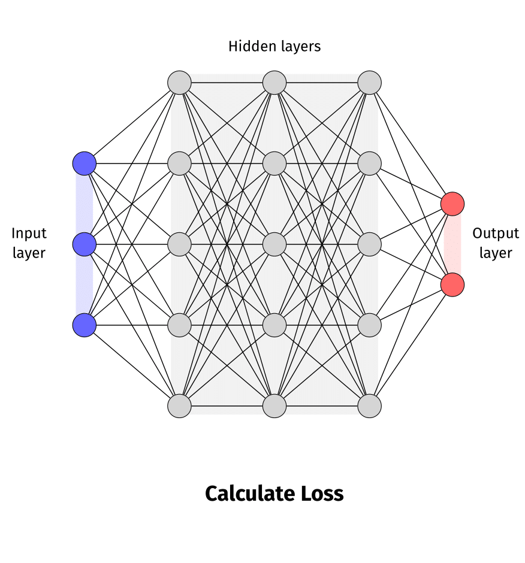

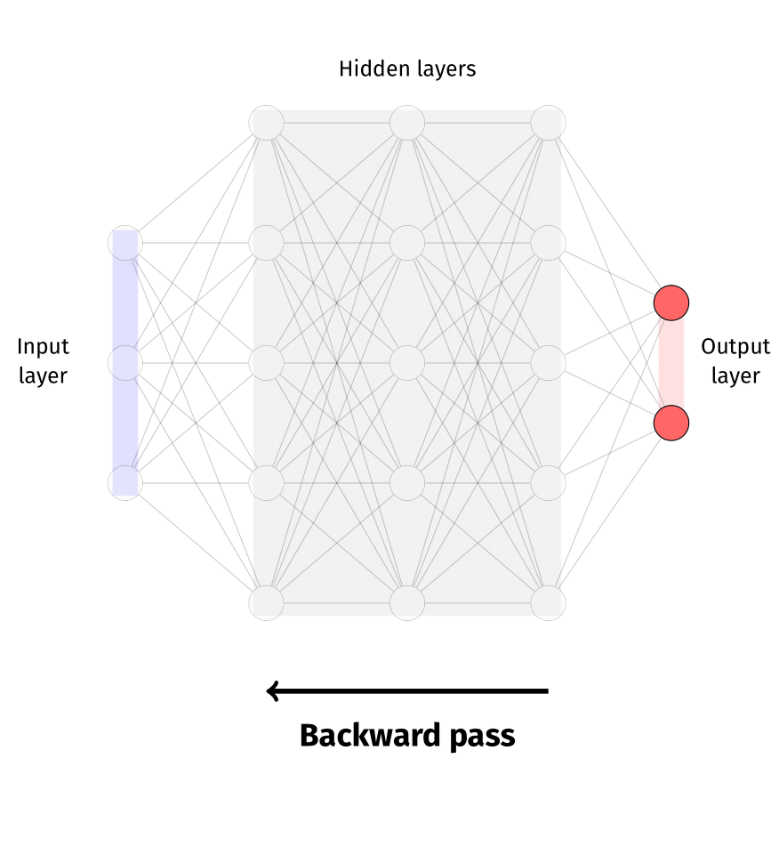

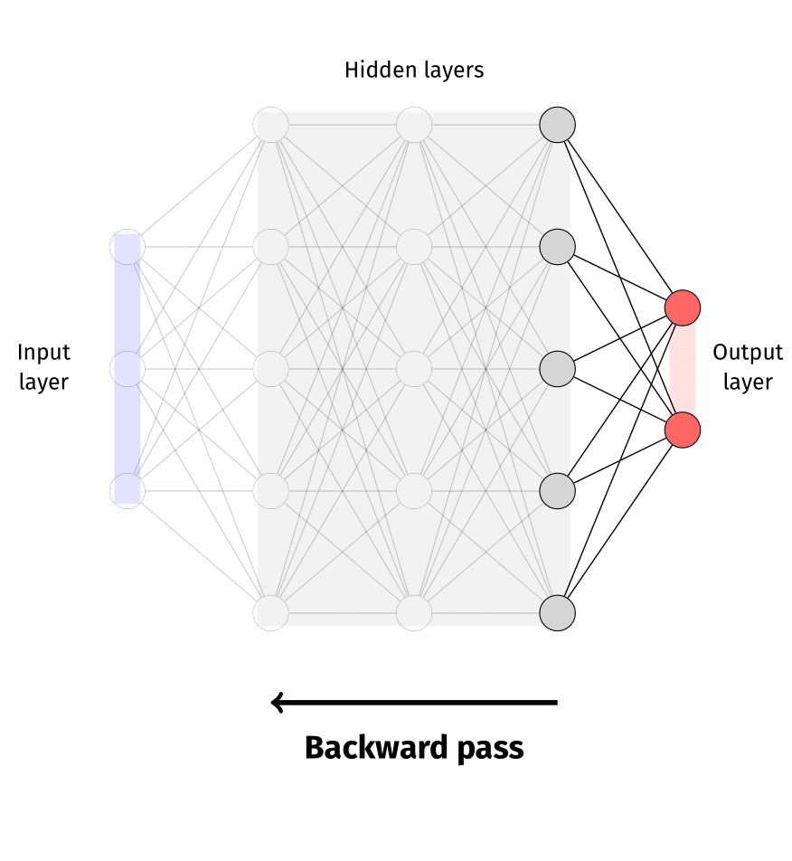

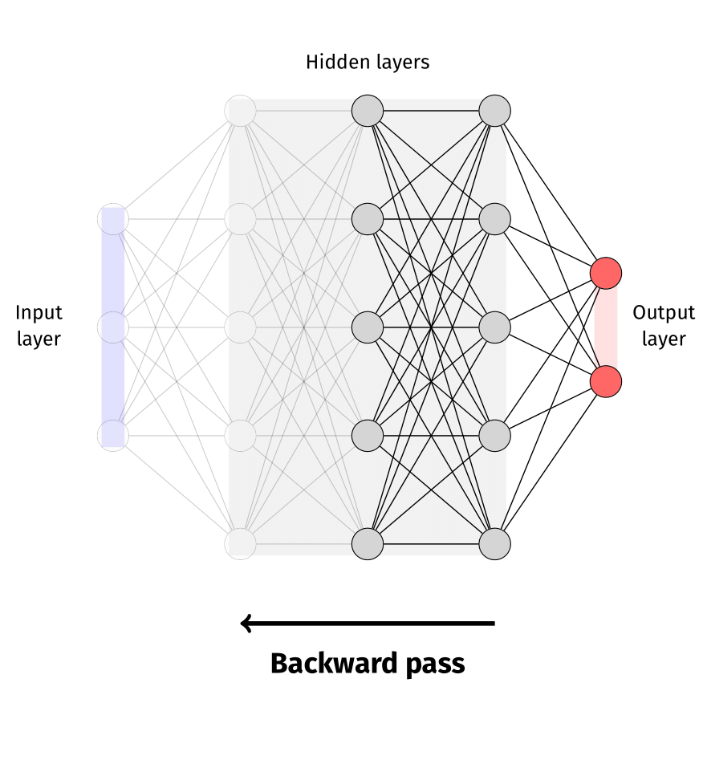

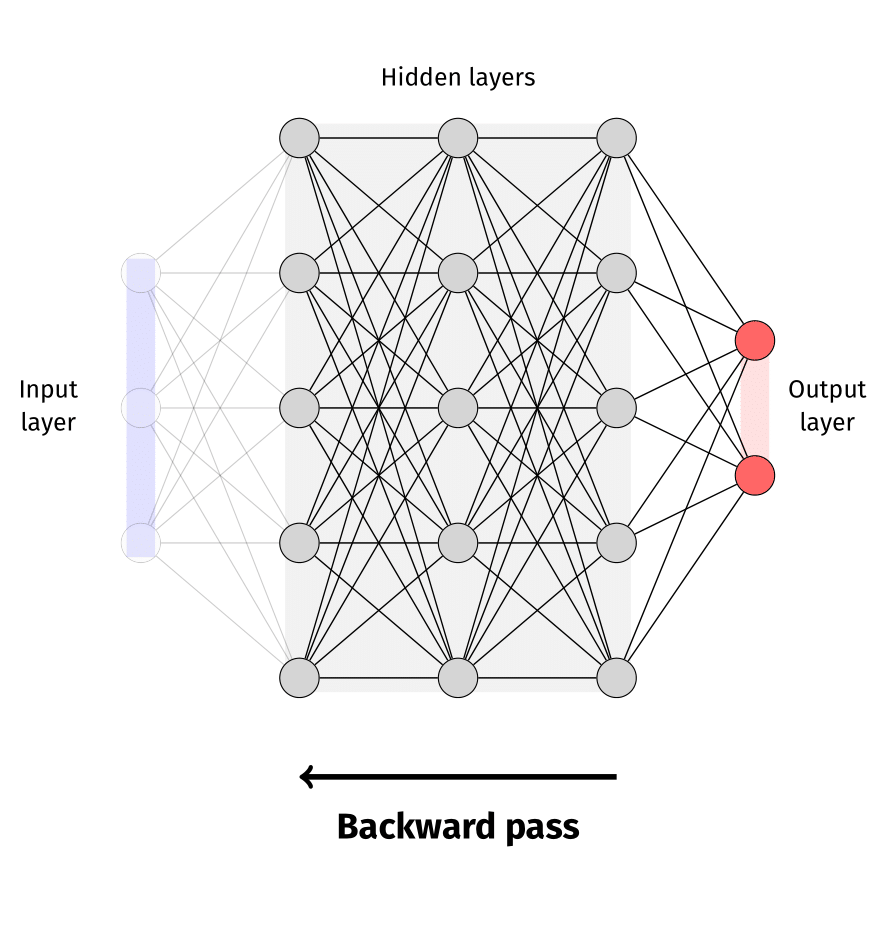

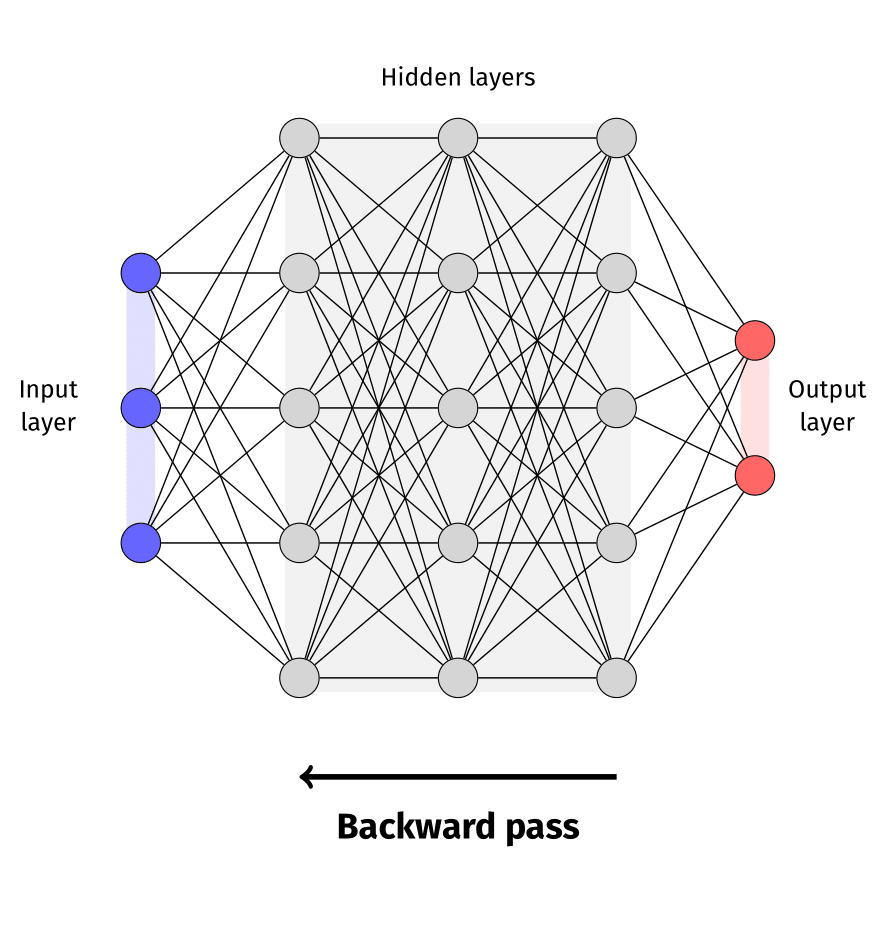

[6 more figures not shown]

## Training a Neural Network: Considerations

**Selecting a learning rate**

- The learning rate determines how much model weights are updated in each step of gradient descent.
  - Too high $\rightarrow$ The model may overshoot minimum, causing instability.
  - Too low $\rightarrow$ The model learns slowly and may get stuck in suboptimal solutions.

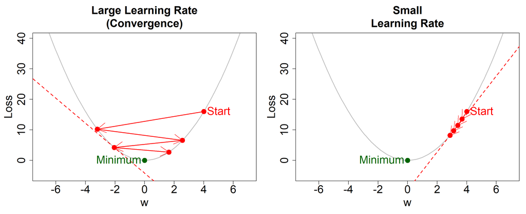

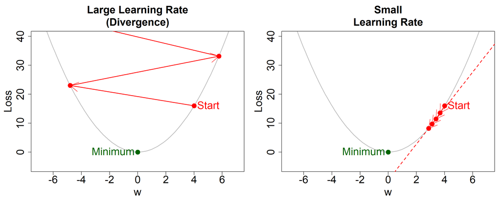

## Training a Neural Network: Considerations

**Selecting a learning rate**

- The learning rate determines how much model weights are updated in each step of gradient descent.
  - Too high $\rightarrow$ The model may overshoot minimum, causing instability.
  - Too low $\rightarrow$ The model learns slowly and may get stuck in suboptimal solutions.
- Solutions:
  - Learning rate schedulers: reduce the learning rate as you proceed to avoid overshooting.
  - Optimisers: adjust the learning rate automatically as you go along, based on gradient history.

**How many epochs to train for?**

- An epoch is one full pass through the training data
  - Too few epochs $\rightarrow$ Underfitting (model doesn’t learn enough patterns).
  - Too many epochs $\rightarrow$ Overfitting (model memorizes training data instead of generalizing).
- Solution:
  - Early stopping: stop when validation loss appears to have passed minimum (validation set used only for evaluation, not to update the parameters)

## Training a Neural Network

Summary:

- Training is **iterative** as compared to (e.g.) naive Bayes which is **one and done**.
- Each iteration incrementally improves performance.
- Due to the large number of parameters, training is **computationally expensive**.

# Neural language modelling

## What is a language model?

A **language model** is any model that represents text data probabilistically, learning patterns in how words appear together in order to make predictions, classify text, or generate new content.

1. **Causal language model:** predicts next word, given word history.
- “Can you predict the next word in this [MASK]”
- e.g. GPT (Generative Pretrained Transformers)
2. **Masked language model:** predicts missing word, given surrounding words.
- “Can you guess which [MASK] is missing from this sentence?”
- e.g. BERT (Bidirectional Encoder Representations from Transformers)

## How can we use NN to model language?

#### What are the inputs?

- One-hot encodings
- Precomputed word-type embeddings

#### What are the outputs?

- Probability distribution over word-types

#### What architecture?

- Feed forward neural network
- Recurrent neural network
- Transformers

$$\begin{align}
w_{\text{debt}} &= \begin{bmatrix}
0 & 0 & 1 & 0 & 0 & 0 & 0 & 0 & 0 & ...& 0
\end{bmatrix}
\end{align}$$

$$\begin{align}
w_{\text{debt}} &= \begin{bmatrix}
0.63 & 0.14 & 0.02 & -0.58 & ...& -0.66
\end{bmatrix}
\end{align}$$

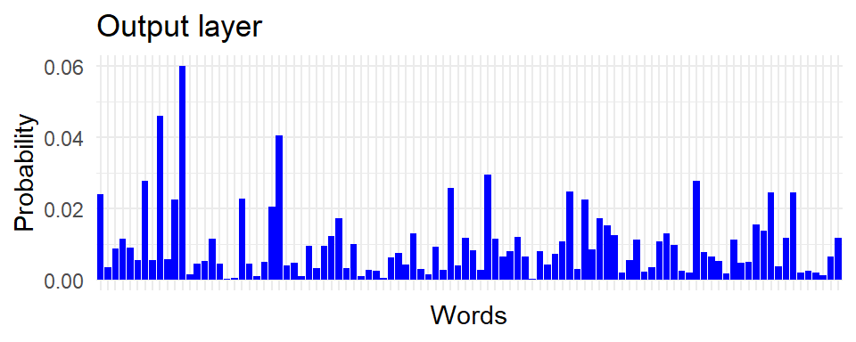

## Model Architectures

#### Feed forward neural network

Information flow is unidirectional

1. Input: Concatenated word embeddings
2. Hidden layer
3. Output: softmax over full vocabulary

**Problem:** Does not capture word order well

- Learns different weights for each relative position
- No explicit modelling of sequences

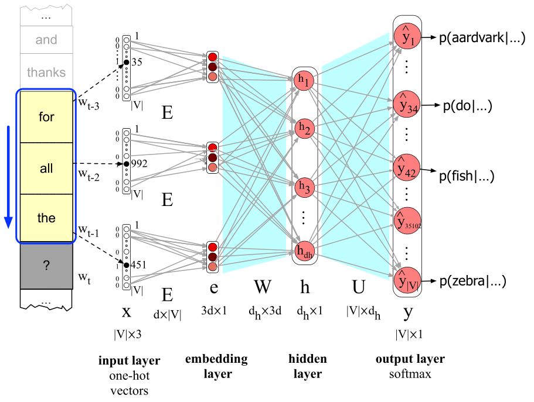

## Model Architectures

#### Recurrent Neural Network

Contains ‘cycles’, passes information across ‘time steps’

- **Pro:** Deals well with short-range sequential dependencies
  - e.g. “It’s time to eat [MASK]”
- **Con:** Struggles with long range dependencies
  - e.g. “I’m so hungry, I didn’t have time for [MASK]”

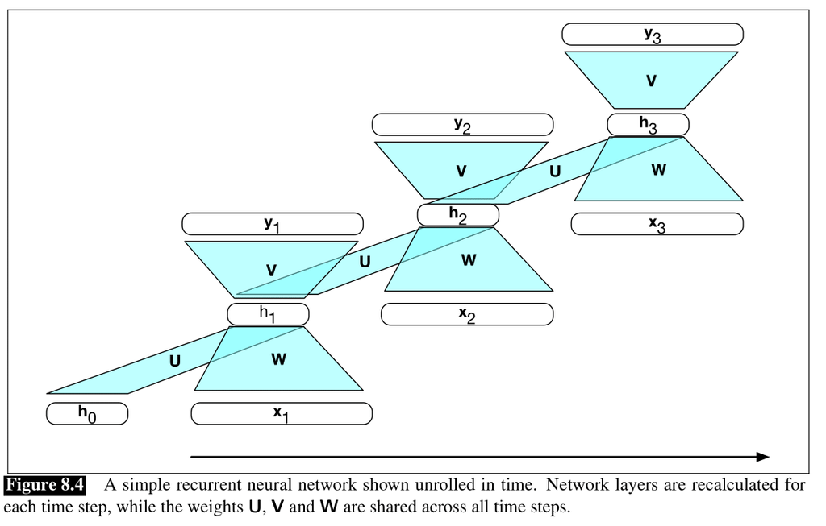

## The Transformer Architecture

High level summary:

- Transformers have become the ‘go-to’ for state-of-the-art NLP, and underly the recent massive advancements in AI.
- Solves the problem of longe range dependencies through a mechanism called **attention**.
- Allows for parallelisation (i.e. computationally efficient)

## The Transformer Architecture

You have already seen a transformer model: **sentence-BERT**. Now let’s complicate this simplified representation…

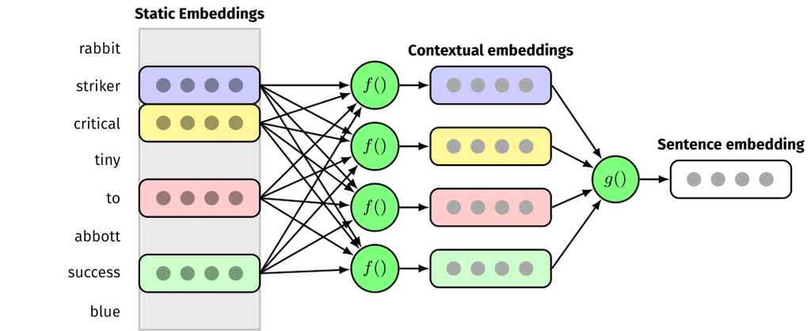

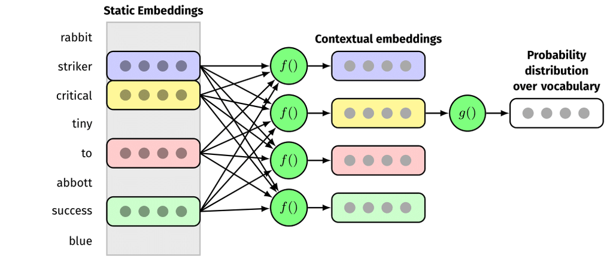

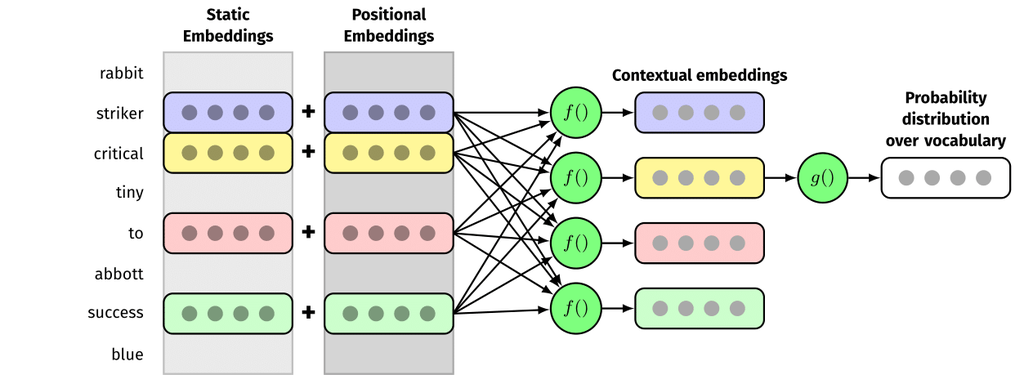

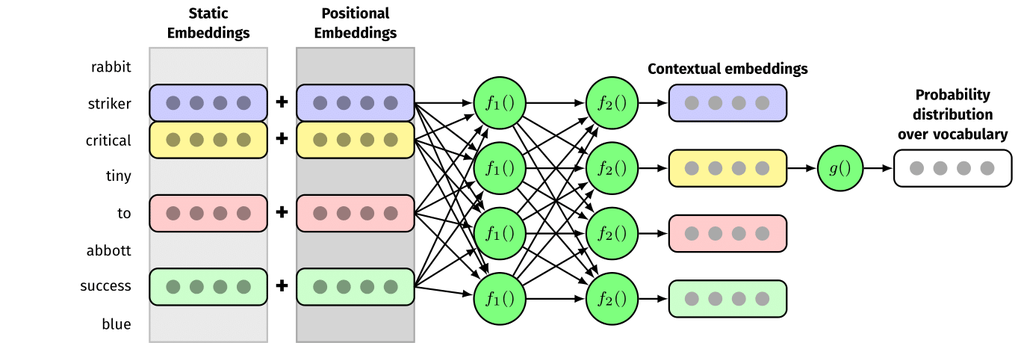